# Lab07: Fine-Tuning & Custom Dataset (Solution)

## Objective:

In this lab, you will learn to:

1. Create a custom dataset using [torch.utils.data.Dataset](https://pytorch.org/docs/stable/data.html).
2. Fine-tune a pretrained model in three different ways:
   - Full fine-tuning (update all layers).
   - Fine-tune only specific layers.
   - Fine-tune only the classification layer.
3. Save the trained model using [safetensor](https://huggingface.co/docs/safetensors/).

## Outline

1. Initialization and Helper functions
2. Section 1: Creating a Custom Dataset
3. Section 2: Customizing a Pretrained Model
   - 2.1 Show the requires_grad of all layers
   - 2.2 Create a function to customize models
4. Section 3: Training from scratch
5. Section 4: Pretrained Model as Feature Extractor
6. Section 5: Finetune Layer4 and FC layer
7. Section 6: Finetune all layers
8. Section 7: Visualize the result

```python
import kagglehub
import wandb


import torch
import torch.nn as nn
import torch.optim as optim
from torchvision.transforms import v2

import matplotlib.pyplot as plt
import numpy as np

from kaggle_secrets import UserSecretsClient

# Load your libraries here
import os
import glob
from PIL import Image

from sklearn.model_selection import StratifiedShuffleSplit
from torch.utils.data import Dataset, DataLoader, SubsetRandomSampler

from safetensors.torch import load_file
from safetensors.torch import save_file

from torchvision.models import resnet18, ResNet18_Weights
```

### Initialization and Helper functions

Log into W&B for logging.

```python
user_secrets = UserSecretsClient()
wandb_api_key = user_secrets.get_secret("WANDB_API_KEY")
status = wandb.login(key=wandb_api_key)
if (status):
    print('Successfully logged into W&B')
else:
    print('Unable to log into W&B')
```

```
wandb: WARNING If you're specifying your api key in code, ensure this code is not shared publicly.
wandb: WARNING Consider setting the WANDB_API_KEY environment variable, or running `wandb login` from the command line.
wandb: Appending key for api.wandb.ai to your netrc file: /root/.netrc
```

```
Successfully logged into W&B
```

```python
def train_one_epoch(epoch, model, train_loader, criterion, optimizer, device, log_step=22):
    model.train()
    running_loss = 0.0
    running_loop = 0.0

    for i, (inputs, labels) in enumerate(train_loader):

        inputs, labels = inputs.to(device), labels.to(device)

        optimizer.zero_grad()
        outputs = model(inputs)
        loss = criterion(outputs, labels)
        loss.backward()
        optimizer.step()

        # train loss is the averaged over multiple iterations
        running_loss += loss.item()
        running_loop += 1
        train_loss = running_loss / running_loop

        if i % log_step == log_step - 1 or i == len(train_loader) - 1:
            print(f'[Epoch {epoch + 1:2d}, iter {i + 1:5d}] train_loss: {train_loss:.3f}')
            running_loss = 0.0
            running_loop = 0.0

    return train_loss
```

```python
def evaluate(model, test_loader, criterion, device):
    model.eval()
    correct = 0
    total = 0
    test_loss = 0.0
    with torch.inference_mode():
        for inputs, labels in test_loader:
            inputs, labels = inputs.to(device), labels.to(device)
            outputs = model(inputs)
            loss = criterion(outputs, labels)
            test_loss += loss.item()
            _, predicted = torch.max(outputs.data, 1)
            total += labels.size(0)
            correct += (predicted == labels).sum().item()

    test_loss = test_loss / len(test_loader.dataset)
    test_acc = 100 * correct / total

    return test_loss, test_acc
```

```python
def train(model, optimizer, criterion, train_loader, test_loader, config, device):

    for epoch in range(config['num_epochs']):
        train_loss = train_one_epoch(epoch, model, train_loader, criterion, optimizer, device)
        test_loss, test_acc = evaluate(model, test_loader, criterion, device)

        print(f"--> Epoch {epoch+1} completed. Train Loss: {train_loss:.3f}, Test Loss: {test_loss:.3f}, Test Accuracy: {test_acc:.2f}%\n")
        wandb.log({"Train Loss": train_loss, "Test Loss": test_loss, "Test Accuracy": test_acc})
```

```python
loss_function = nn.CrossEntropyLoss()
```

```python
device = torch.device("cuda" if torch.cuda.is_available() else "cpu")
```

# Section 1: Creating a Custom Dataset

#### Download the dataset

Download and prepare the [chest X-ray (CXR) image dataset](https://www.kaggle.com/datasets/sachinkumar413/covid-pneumonia-normal-chest-xray-images) [1]. The dataset has 3 classes:

1. covid: 1626 images
2. normal: 1802 images
3. pneunomia: 1800 images

Reference:

- [1] Shastri, S., Kansal, I., Kumar, S. et al. [CheXImageNet: a novel architecture for accurate classification of Covid-19 with chest x-ray digital images using deep convolutional neural networks. Health Technol. 12, 193–204 (2022). https://doi.org/10.1007/s12553-021-00630-x.

```python
path = kagglehub.dataset_download("sachinkumar413/covid-pneumonia-normal-chest-xray-images")
classes = os.listdir(path)
num_classes = len(classes)

print(f'{path = }')
print(f'{classes = }')
print(f'{num_classes = }')
```

```
path = '/kaggle/input/covid-pneumonia-normal-chest-xray-images'
classes = ['PNEUMONIA', 'NORMAL', 'COVID']
num_classes = 3
```

Show the number of samples in each class

```python
for cls in os.listdir(path):
    cls_path = os.path.join(path, cls)
    cls_filelist = os.listdir(cls_path)
    print(f'Class: {cls:10s}: Number of samples = {len(cls_filelist)}')
```

```
Class: PNEUMONIA : Number of samples = 1800
Class: NORMAL    : Number of samples = 1802
Class: COVID     : Number of samples = 1626
```

#### Implement the Custom Dataset

Implement the custom dataset class

```python
class ChestXRayDataset(Dataset):
    def __init__(self, path, transform=None):
        self.path = path
        self.transform = transform
        self.classes = os.listdir(path)
        self.targets = []
        self.images_path = []

        for i, cls in enumerate(classes):
            cls_path = os.path.join(path, cls)
            cls_samples = [os.path.join(cls_path, filename) for filename in os.listdir(cls_path)]
            self.images_path += cls_samples
            self.targets += [i]*len(cls_samples)

    def __len__(self):
        return len(self.targets)


    def __getitem__(self, idx):
        filename = os.path.join(self.path, self.images_path[idx])
        x = Image.open(filename).convert("RGB")
        if self.transform is not None:
            x = self.transform(x)
        y = self.targets[idx]

        return x, y
```

Create a dataset and get one sample.

```python
dataset = ChestXRayDataset(path)
print('Number of samples:', len(dataset))
```

```
Number of samples: 5228
```

```
Image 2: Label = 2 (COVID), resolution = (232, 232)
```

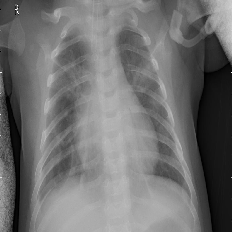

```python
index = 2
img, target = dataset[index]
print(f'Image {index}: Label = {index} ({dataset.classes[index]}), resolution = {img.size}')
img
```

#### Create the transformation pipeline

Define the transformation pipeline and create a dataset with it.

```python
transform = v2.Compose([
    v2.ToImage(),
    v2.Resize((224, 224)),
    v2.ToDtype(torch.float32, scale=True),
    v2.Normalize(mean=[0.5, 0.5, 0.5], std=[0.29, 0.29, 0.29])
])
```

```python
dataset = ChestXRayDataset(path, transform=transform)

x, y = dataset[0]
print(f'class = {dataset.classes[y]} (y={y})')
print(f'Shape of x: {x.shape}')
```

```
class = PNEUMONIA (y=0)
Shape of x: torch.Size([3, 224, 224])
```

#### Create the stratified sampling and data loader

Split the dataset into two: 80% for training and 20% for validation.

1. Use [sklearn.model_selection.StratifiedShuffleSplit](https://scikit-learn.org/stable/modules/generated/sklearn.model_selection.StratifiedShuffleSplit.html) to ensure that samples are drawn proportionally from each class. Set `n_splits=1` and `random_state=42`. The function returns a list of indices for each split.
2. Use torch.utils.data.SubsetRandomSampler define a random sampler that randomly samples the provided list of indices.
3. Use the subset random sampler rather than the default random sampler for the torch.utils.data.DataLoader. We will use this random sampler rather than the default random sampler for our DataLoader.

Split the dataset and get the indices of training and validation set.

```python
from sklearn.model_selection import StratifiedShuffleSplit

splitter = StratifiedShuffleSplit(n_splits=1, test_size=0.2, random_state=42)
train_idx, val_idx = next(splitter.split(dataset.images_path, dataset.targets))

print('Number of training samples:', len(train_idx), "| indices:", train_idx)
print('Number of val samples     :', len(val_idx), "| indices:", val_idx)
```

```
Number of training samples: 4182 | indices: [1992 1361 4737 ... 1548  811 3142]
Number of val samples     : 1046 | indices: [2926  143 4853 ... 3080 1808 3912]
```

Define the subset random sampler.

```python
from torch.utils.data import SubsetRandomSampler

train_sampler = SubsetRandomSampler(train_idx)
val_sampler   = SubsetRandomSampler(val_idx)
```

Create the data loader using the subset random sampler.

```python
from torch.utils.data import DataLoader

train_loader = DataLoader(dataset, batch_size=64, sampler=train_sampler)
val_loader   = DataLoader(dataset, batch_size=64, sampler=val_sampler)

print('Number of training samples   :', len(train_idx))
print('Number of validation samples :', len(val_idx))
```

```
Number of training samples   : 4182
Number of validation samples : 1046
```

```python
x_batch, y_batch = next(iter(train_loader))
print(f'{x_batch.shape = }')
print(f'{y_batch.shape = }')
```

```
x_batch.shape = torch.Size([64, 3, 224, 224])
y_batch.shape = torch.Size([64])
```

# Section 2: Customizing a Pretrained Model

#### 2.1 Show the requires_grad of all layers

First, create a function that is able to show the `requires_grad` of all layers in the network.

```python
def show_model(model):
    for name, layer in model.named_parameters():
        print(f'{name:28} | requires_grad = {layer.requires_grad}')
```

```python
model = resnet18(weights=None)
show_model(model)
```

```
conv1.weight                 | requires_grad = True
bn1.weight                   | requires_grad = True
bn1.bias                     | requires_grad = True
layer1.0.conv1.weight        | requires_grad = True
layer1.0.bn1.weight          | requires_grad = True
layer1.0.bn1.bias            | requires_grad = True
layer1.0.conv2.weight        | requires_grad = True
layer1.0.bn2.weight          | requires_grad = True
layer1.0.bn2.bias            | requires_grad = True
layer1.1.conv1.weight        | requires_grad = True
layer1.1.bn1.weight          | requires_grad = True
layer1.1.bn1.bias            | requires_grad = True
layer1.1.conv2.weight        | requires_grad = True
layer1.1.bn2.weight          | requires_grad = True
layer1.1.bn2.bias            | requires_grad = True
layer2.0.conv1.weight        | requires_grad = True
layer2.0.bn1.weight          | requires_grad = True
layer2.0.bn1.bias            | requires_grad = True
layer2.0.conv2.weight        | requires_grad = True
layer2.0.bn2.weight          | requires_grad = True
layer2.0.bn2.bias            | requires_grad = True
layer2.0.downsample.0.weight | requires_grad = True
layer2.0.downsample.1.weight | requires_grad = True
layer2.0.downsample.1.bias   | requires_grad = True
layer2.1.conv1.weight        | requires_grad = True
layer2.1.bn1.weight          | requires_grad = True
layer2.1.bn1.bias            | requires_grad = True
layer2.1.conv2.weight        | requires_grad = True
layer2.1.bn2.weight          | requires_grad = True
layer2.1.bn2.bias            | requires_grad = True
layer3.0.conv1.weight        | requires_grad = True
layer3.0.bn1.weight          | requires_grad = True
layer3.0.bn1.bias            | requires_grad = True
layer3.0.conv2.weight        | requires_grad = True
layer3.0.bn2.weight          | requires_grad = True
layer3.0.bn2.bias            | requires_grad = True
layer3.0.downsample.0.weight | requires_grad = True
layer3.0.downsample.1.weight | requires_grad = True
layer3.0.downsample.1.bias   | requires_grad = True
layer3.1.conv1.weight        | requires_grad = True
layer3.1.bn1.weight          | requires_grad = True
layer3.1.bn1.bias            | requires_grad = True
layer3.1.conv2.weight        | requires_grad = True
layer3.1.bn2.weight          | requires_grad = True
layer3.1.bn2.bias            | requires_grad = True
layer4.0.conv1.weight        | requires_grad = True
layer4.0.bn1.weight          | requires_grad = True
layer4.0.bn1.bias            | requires_grad = True
layer4.0.conv2.weight        | requires_grad = True
layer4.0.bn2.weight          | requires_grad = True
layer4.0.bn2.bias            | requires_grad = True
layer4.0.downsample.0.weight | requires_grad = True
layer4.0.downsample.1.weight | requires_grad = True
layer4.0.downsample.1.bias   | requires_grad = True
layer4.1.conv1.weight        | requires_grad = True
layer4.1.bn1.weight          | requires_grad = True
layer4.1.bn1.bias            | requires_grad = True
layer4.1.conv2.weight        | requires_grad = True
layer4.1.bn2.weight          | requires_grad = True
layer4.1.bn2.bias            | requires_grad = True
fc.weight                    | requires_grad = True
fc.bias                      | requires_grad = True
```

#### 2.2 Create a function to customize models

In this section, we implement a function that allows us to build a resnet model with the following settings:

| Settings | weights | Finetuned layers |
| --- | --- | --- |
| Training from scratch | `None` | N/A |
| Pretrained model as a feature extractor | `ResNet18_Weights.IMAGENET1K_V1` | `'output'` |
| Finetuning top layers | `ResNet18_Weights.IMAGENET1K_V1` | `['layer4', 'fc']` |
| Finetuning all layers | `ResNet18_Weights.IMAGENET1K_V1` | `'all'` |

```python
def build_model(num_classes, config, device=torch.device("cpu"), return_optimizer=True):

    # load the pretrained model
    model = resnet18(weights=config['weights']).to(device)

    if config['weights'] is None:
        # Training from scratch - enable all layers
        pass
    elif config['finetuned_layers'] == 'output':
        # Use pretrained model as a feature extractor - disable all layers
        for param in model.parameters():
            param.requires_grad = False
    elif config['finetuned_layers'] == 'all':
        # Finetune all layers - enable all layers
        pass
    else:
        # freeze the layers that are not listed in config['finetuned_layers']
        for name, layer in model.named_parameters():
            if not any([name.startswith(layer_name) for layer_name in config['finetuned_layers']]):
                layer.requires_grad = False

    # replace the classification layer
    model.fc = nn.Linear(model.fc.in_features, num_classes).to(device)

    # transfer model to GPU if available
    model = model.to(device)

    # return model only
    if not return_optimizer:
        return model

    # create the optimizer
    optimizer = optim.SGD(model.parameters(), lr=config['lr'], momentum=config['momentum'])

    # return model and optimizer
    return model, optimizer
```

Test your code here.

```python
config =  {
    'weights'         : None,
    'finetuned_layers': None,
    'lr'              : 0.001,
    'momentum'        : 0.9,
    'num_epochs'      : 10
}
```

```python
model, optimizer = build_model(num_classes, config, device)
show_model(model)
```

```
Weights         : None
Finetuned layer : None

conv1.weight                 | requires_grad = True
bn1.weight                   | requires_grad = True
bn1.bias                     | requires_grad = True
layer1.0.conv1.weight        | requires_grad = True
layer1.0.bn1.weight          | requires_grad = True
layer1.0.bn1.bias            | requires_grad = True
layer1.0.conv2.weight        | requires_grad = True
layer1.0.bn2.weight          | requires_grad = True
layer1.0.bn2.bias            | requires_grad = True
layer1.1.conv1.weight        | requires_grad = True
layer1.1.bn1.weight          | requires_grad = True
layer1.1.bn1.bias            | requires_grad = True
layer1.1.conv2.weight        | requires_grad = True
layer1.1.bn2.weight          | requires_grad = True
layer1.1.bn2.bias            | requires_grad = True
layer2.0.conv1.weight        | requires_grad = True
layer2.0.bn1.weight          | requires_grad = True
layer2.0.bn1.bias            | requires_grad = True
layer2.0.conv2.weight        | requires_grad = True
layer2.0.bn2.weight          | requires_grad = True
layer2.0.bn2.bias            | requires_grad = True
layer2.0.downsample.0.weight | requires_grad = True
layer2.0.downsample.1.weight | requires_grad = True
layer2.0.downsample.1.bias   | requires_grad = True
layer2.1.conv1.weight        | requires_grad = True
layer2.1.bn1.weight          | requires_grad = True
layer2.1.bn1.bias            | requires_grad = True
layer2.1.conv2.weight        | requires_grad = True
layer2.1.bn2.weight          | requires_grad = True
layer2.1.bn2.bias            | requires_grad = True
layer3.0.conv1.weight        | requires_grad = True
layer3.0.bn1.weight          | requires_grad = True
layer3.0.bn1.bias            | requires_grad = True
layer3.0.conv2.weight        | requires_grad = True
layer3.0.bn2.weight          | requires_grad = True
layer3.0.bn2.bias            | requires_grad = True
layer3.0.downsample.0.weight | requires_grad = True
```

[output cut: 10 more lines]

```
layer4.0.bn1.bias            | requires_grad = True
layer4.0.conv2.weight        | requires_grad = True
layer4.0.bn2.weight          | requires_grad = True
layer4.0.bn2.bias            | requires_grad = True
layer4.0.downsample.0.weight | requires_grad = True
layer4.0.downsample.1.weight | requires_grad = True
layer4.0.downsample.1.bias   | requires_grad = True
layer4.1.conv1.weight        | requires_grad = True
layer4.1.bn1.weight          | requires_grad = True
layer4.1.bn1.bias            | requires_grad = True
layer4.1.conv2.weight        | requires_grad = True
layer4.1.bn2.weight          | requires_grad = True
layer4.1.bn2.bias            | requires_grad = True
fc.weight                    | requires_grad = True
fc.bias                      | requires_grad = True
```

# Section 3: Training from scratch

Setting for current run:

```python
config =  {
    'weights'         : None,
    'finetuned_layers': None,
    'lr'              : 0.001,
    'momentum'        : 0.9,
    'num_epochs'      : 10
}
```

Initialize a wandb session ([wandb.init](https://docs.wandb.ai/ref/python/init/)) to log the current project. Set the project name to `Lab07 - Finetuning & Custom Dataset`.

```python
wandb.init(
    project='Lab07 - Finetuning & Custom Dataset',
    name = 'Training from scratch',
    config = config
)
```

Tracking run with wandb version 0.19.1

Run data is saved locally in `/kaggle/working/wandb/run-20250331_094645-gusbmcjl`

Syncing run **[Training from scratch](https://wandb.ai/hktan-personal/Lab07%20-%20Finetuning%20%26%20Custom%20Dataset/runs/gusbmcjl)** to [Weights & Biases](https://wandb.ai/hktan-personal/Lab07%20-%20Finetuning%20%26%20Custom%20Dataset) ([docs](https://wandb.me/developer-guide))

View project at https://wandb.ai/hktan-personal/Lab07%20-%20Finetuning%20%26%20Custom%20Dataset

View run at https://wandb.ai/hktan-personal/Lab07%20-%20Finetuning%20%26%20Custom%20Dataset/runs/gusbmcjl

[interactive chart not shown]

Create and train the model from scratch.

```python
model1, optimizer1 = build_model(num_classes, config, device)
train(model1, optimizer1, loss_function, train_loader, val_loader, config, device)
```

```
Weights         : None
Finetuned layer : None

[Epoch  1, iter    22] train_loss: 0.937
[Epoch  1, iter    44] train_loss: 0.660
[Epoch  1, iter    66] train_loss: 0.517
--> Epoch 1 completed. Train Loss: 0.517, Test Loss: 0.002, Test Accuracy: 77.06%

[Epoch  2, iter    22] train_loss: 0.420
[Epoch  2, iter    44] train_loss: 0.364
[Epoch  2, iter    66] train_loss: 0.312
--> Epoch 2 completed. Train Loss: 0.312, Test Loss: 0.001, Test Accuracy: 90.73%

[Epoch  3, iter    22] train_loss: 0.267
[Epoch  3, iter    44] train_loss: 0.236
[Epoch  3, iter    66] train_loss: 0.244
--> Epoch 3 completed. Train Loss: 0.244, Test Loss: 0.001, Test Accuracy: 90.92%

[Epoch  4, iter    22] train_loss: 0.198
[Epoch  4, iter    44] train_loss: 0.199
[Epoch  4, iter    66] train_loss: 0.191
--> Epoch 4 completed. Train Loss: 0.191, Test Loss: 0.001, Test Accuracy: 82.12%

[Epoch  5, iter    22] train_loss: 0.172
[Epoch  5, iter    44] train_loss: 0.166
[Epoch  5, iter    66] train_loss: 0.166
--> Epoch 5 completed. Train Loss: 0.166, Test Loss: 0.001, Test Accuracy: 81.93%

[Epoch  6, iter    22] train_loss: 0.140
[Epoch  6, iter    44] train_loss: 0.159
[Epoch  6, iter    66] train_loss: 0.133
--> Epoch 6 completed. Train Loss: 0.133, Test Loss: 0.001, Test Accuracy: 93.69%

[Epoch  7, iter    22] train_loss: 0.117
[Epoch  7, iter    44] train_loss: 0.121
[Epoch  7, iter    66] train_loss: 0.133
--> Epoch 7 completed. Train Loss: 0.133, Test Loss: 0.001, Test Accuracy: 80.11%

[Epoch  8, iter    22] train_loss: 0.106
[Epoch  8, iter    44] train_loss: 0.117
[Epoch  8, iter    66] train_loss: 0.110
--> Epoch 8 completed. Train Loss: 0.110, Test Loss: 0.001, Test Accuracy: 92.07%

[Epoch  9, iter    22] train_loss: 0.094
[Epoch  9, iter    44] train_loss: 0.091
[Epoch  9, iter    66] train_loss: 0.106
--> Epoch 9 completed. Train Loss: 0.106, Test Loss: 0.001, Test Accuracy: 89.01%

[Epoch 10, iter    22] train_loss: 0.087
[Epoch 10, iter    44] train_loss: 0.078
[Epoch 10, iter    66] train_loss: 0.092
--> Epoch 10 completed. Train Loss: 0.092, Test Loss: 0.002, Test Accuracy: 79.16%
```

Close W&B

```python
wandb.finish()
```

Run history:

| Test Accuracy | ▁▇▇▃▃█▂▇▆▂ |
| --- | --- |
| Test Loss | ▆▃▂▄▄▁▅▁▃█ |
| Train Loss | █▅▃▃▂▂▂▁▁▁ |

Run summary:

| Test Accuracy | 79.1587 |
| --- | --- |
| Test Loss | 0.00213 |
| Train Loss | 0.09229 |

View run **Training from scratch** at: https://wandb.ai/hktan-personal/Lab07%20-%20Finetuning%20%26%20Custom%20Dataset/runs/gusbmcjl  
View project at: https://wandb.ai/hktan-personal/Lab07%20-%20Finetuning%20%26%20Custom%20Dataset  
Synced 5 W&B file(s), 0 media file(s), 0 artifact file(s) and 0 other file(s)

Find logs at: `./wandb/run-20250331_094645-gusbmcjl/logs`

# Section 4: Pretrained Model as Feature Extractor

```python
config =  {
    'weights'         : ResNet18_Weights.IMAGENET1K_V1,
    'finetuned_layers': 'output',
    'lr'              : 0.001,
    'momentum'        : 0.9,
    'num_epochs'      : 10
}
```

Initialize W&B.

```python
wandb.init(
    project='Lab07 - Finetuning & Custom Dataset',
    name = 'output layer',
    config = config
)
```

Tracking run with wandb version 0.19.1

Run data is saved locally in `/kaggle/working/wandb/run-20250331_095434-6jpimiog`

View project at https://wandb.ai/hktan-personal/Lab07%20-%20Finetuning%20%26%20Custom%20Dataset

View run at https://wandb.ai/hktan-personal/Lab07%20-%20Finetuning%20%26%20Custom%20Dataset/runs/6jpimiog

[interactive chart not shown]

Create and train the model.

```python
model2, optimizer2 = build_model(num_classes, config, device)
train(model2, optimizer2, loss_function, train_loader, val_loader, config, device)
```

```
Weights         : ResNet18_Weights.IMAGENET1K_V1
Finetuned layer : output

[Epoch  1, iter    22] train_loss: 0.899
[Epoch  1, iter    44] train_loss: 0.467
[Epoch  1, iter    66] train_loss: 0.352
--> Epoch 1 completed. Train Loss: 0.352, Test Loss: 0.001, Test Accuracy: 90.54%

[Epoch  2, iter    22] train_loss: 0.302
[Epoch  2, iter    44] train_loss: 0.281
[Epoch  2, iter    66] train_loss: 0.267
--> Epoch 2 completed. Train Loss: 0.267, Test Loss: 0.001, Test Accuracy: 92.83%

[Epoch  3, iter    22] train_loss: 0.251
[Epoch  3, iter    44] train_loss: 0.251
[Epoch  3, iter    66] train_loss: 0.216
--> Epoch 3 completed. Train Loss: 0.216, Test Loss: 0.001, Test Accuracy: 93.12%

[Epoch  4, iter    22] train_loss: 0.224
[Epoch  4, iter    44] train_loss: 0.213
[Epoch  4, iter    66] train_loss: 0.212
--> Epoch 4 completed. Train Loss: 0.212, Test Loss: 0.001, Test Accuracy: 93.59%

[Epoch  5, iter    22] train_loss: 0.205
[Epoch  5, iter    44] train_loss: 0.196
[Epoch  5, iter    66] train_loss: 0.189
--> Epoch 5 completed. Train Loss: 0.189, Test Loss: 0.001, Test Accuracy: 93.50%

[Epoch  6, iter    22] train_loss: 0.194
[Epoch  6, iter    44] train_loss: 0.181
[Epoch  6, iter    66] train_loss: 0.187
--> Epoch 6 completed. Train Loss: 0.187, Test Loss: 0.001, Test Accuracy: 93.98%

[Epoch  7, iter    22] train_loss: 0.174
[Epoch  7, iter    44] train_loss: 0.171
[Epoch  7, iter    66] train_loss: 0.185
--> Epoch 7 completed. Train Loss: 0.185, Test Loss: 0.001, Test Accuracy: 93.50%

[Epoch  8, iter    22] train_loss: 0.171
[Epoch  8, iter    44] train_loss: 0.152
[Epoch  8, iter    66] train_loss: 0.191
--> Epoch 8 completed. Train Loss: 0.191, Test Loss: 0.001, Test Accuracy: 93.98%

[Epoch  9, iter    22] train_loss: 0.179
[Epoch  9, iter    44] train_loss: 0.171
[Epoch  9, iter    66] train_loss: 0.152
--> Epoch 9 completed. Train Loss: 0.152, Test Loss: 0.001, Test Accuracy: 93.50%

[Epoch 10, iter    22] train_loss: 0.176
[Epoch 10, iter    44] train_loss: 0.168
[Epoch 10, iter    66] train_loss: 0.166
--> Epoch 10 completed. Train Loss: 0.166, Test Loss: 0.001, Test Accuracy: 94.65%
```

Close the wandb.

```python
wandb.finish()
```

Run history:

| Test Accuracy | ▁▅▅▆▆▇▆▇▆█ |
| --- | --- |
| Test Loss | █▄▃▂▂▁▂▁▁▁ |
| Train Loss | █▅▃▃▂▂▂▂▁▁ |

Run summary:

| Test Accuracy | 94.64627 |
| --- | --- |
| Test Loss | 0.00058 |
| Train Loss | 0.16556 |

Find logs at: `./wandb/run-20250331_095434-6jpimiog/logs`

# Section 5: Finetune Layer4 and FC layer

```python
config =  {
    'weights'         : ResNet18_Weights.IMAGENET1K_V1,
    'finetuned_layers': ['layer4', 'fc'],
    'lr'              : 0.001,
    'momentum'        : 0.9,
    'num_epochs'      : 10
}
```

Initialize W&B.

```python
wandb.init(
    project='Lab07 - Finetuning & Custom Dataset',
    name = 'layer4 and fc layer',
    config = config
)
```

Tracking run with wandb version 0.19.1

Run data is saved locally in `/kaggle/working/wandb/run-20250331_113649-fk1dcgz6`

Syncing run **[layer4 and fc layer](https://wandb.ai/hktan-personal/Lab07%20-%20Finetuning%20%26%20Custom%20Dataset/runs/fk1dcgz6)** to [Weights & Biases](https://wandb.ai/hktan-personal/Lab07%20-%20Finetuning%20%26%20Custom%20Dataset) ([docs](https://wandb.me/developer-guide))

View project at https://wandb.ai/hktan-personal/Lab07%20-%20Finetuning%20%26%20Custom%20Dataset

View run at https://wandb.ai/hktan-personal/Lab07%20-%20Finetuning%20%26%20Custom%20Dataset/runs/fk1dcgz6

[interactive chart not shown]

Create the model.

```python
model3, optimizer3 = build_model(num_classes, config, device)
```

```
Weights         : ResNet18_Weights.IMAGENET1K_V1
Finetuned layer : ['layer4', 'fc']
```

Train the model

```python
train(model3, optimizer3, loss_function, train_loader, val_loader, config, device)
```

```
[Epoch  1, iter    22] train_loss: 0.726
[Epoch  1, iter    44] train_loss: 0.268
[Epoch  1, iter    66] train_loss: 0.190
--> Epoch 1 completed. Train Loss: 0.190, Test Loss: 0.001, Test Accuracy: 92.93%

[Epoch  2, iter    22] train_loss: 0.154
[Epoch  2, iter    44] train_loss: 0.134
[Epoch  2, iter    66] train_loss: 0.129
--> Epoch 2 completed. Train Loss: 0.129, Test Loss: 0.000, Test Accuracy: 95.51%

[Epoch  3, iter    22] train_loss: 0.106
[Epoch  3, iter    44] train_loss: 0.109
[Epoch  3, iter    66] train_loss: 0.093
--> Epoch 3 completed. Train Loss: 0.093, Test Loss: 0.000, Test Accuracy: 96.18%

[Epoch  4, iter    22] train_loss: 0.084
[Epoch  4, iter    44] train_loss: 0.066
[Epoch  4, iter    66] train_loss: 0.088
--> Epoch 4 completed. Train Loss: 0.088, Test Loss: 0.000, Test Accuracy: 96.85%

[Epoch  5, iter    22] train_loss: 0.077
[Epoch  5, iter    44] train_loss: 0.063
[Epoch  5, iter    66] train_loss: 0.060
--> Epoch 5 completed. Train Loss: 0.060, Test Loss: 0.000, Test Accuracy: 97.04%

[Epoch  6, iter    22] train_loss: 0.048
[Epoch  6, iter    44] train_loss: 0.055
[Epoch  6, iter    66] train_loss: 0.048
--> Epoch 6 completed. Train Loss: 0.048, Test Loss: 0.000, Test Accuracy: 97.42%

[Epoch  7, iter    22] train_loss: 0.047
[Epoch  7, iter    44] train_loss: 0.044
[Epoch  7, iter    66] train_loss: 0.040
--> Epoch 7 completed. Train Loss: 0.040, Test Loss: 0.000, Test Accuracy: 97.51%

[Epoch  8, iter    22] train_loss: 0.043
[Epoch  8, iter    44] train_loss: 0.030
[Epoch  8, iter    66] train_loss: 0.034
--> Epoch 8 completed. Train Loss: 0.034, Test Loss: 0.000, Test Accuracy: 97.71%

[Epoch  9, iter    22] train_loss: 0.036
[Epoch  9, iter    44] train_loss: 0.029
[Epoch  9, iter    66] train_loss: 0.019
--> Epoch 9 completed. Train Loss: 0.019, Test Loss: 0.000, Test Accuracy: 97.71%

[Epoch 10, iter    22] train_loss: 0.031
[Epoch 10, iter    44] train_loss: 0.020
[Epoch 10, iter    66] train_loss: 0.020
--> Epoch 10 completed. Train Loss: 0.020, Test Loss: 0.000, Test Accuracy: 97.90%
```

Close the wandb.

```python
wandb.finish()
```

[output not shown]

# Section 6: Finetune all layers

```python
config =  {
    'weights'         : ResNet18_Weights.IMAGENET1K_V1,
    'finetuned_layers': 'all',
    'lr'              : 0.001,
    'momentum'        : 0.9,
    'num_epochs'      : 10
}
```

Initialize W&B.

```python
wandb.init(
    project='Lab07 - Finetuning & Custom Dataset',
    name = 'All layers',
    config = config
)
```

Tracking run with wandb version 0.19.1

Run data is saved locally in `/kaggle/working/wandb/run-20250331_101146-ci3jtmy9`

Syncing run **[All layers](https://wandb.ai/hktan-personal/Lab07%20-%20Finetuning%20%26%20Custom%20Dataset/runs/ci3jtmy9)** to [Weights & Biases](https://wandb.ai/hktan-personal/Lab07%20-%20Finetuning%20%26%20Custom%20Dataset) ([docs](https://wandb.me/developer-guide))

View project at https://wandb.ai/hktan-personal/Lab07%20-%20Finetuning%20%26%20Custom%20Dataset

View run at https://wandb.ai/hktan-personal/Lab07%20-%20Finetuning%20%26%20Custom%20Dataset/runs/ci3jtmy9

[interactive chart not shown]

Create the model.

```python
model4, optimizer4 = build_model(num_classes, config, device)
```

```
Weights         : ResNet18_Weights.IMAGENET1K_V1
Finetuned layer : all
```

Train the model.

```python
train(model4, optimizer4, loss_function, train_loader, val_loader, config, device)
```

```
[Epoch  1, iter    22] train_loss: 0.703
[Epoch  1, iter    44] train_loss: 0.200
[Epoch  1, iter    66] train_loss: 0.134
--> Epoch 1 completed. Train Loss: 0.134, Test Loss: 0.000, Test Accuracy: 95.70%

[Epoch  2, iter    22] train_loss: 0.112
[Epoch  2, iter    44] train_loss: 0.099
[Epoch  2, iter    66] train_loss: 0.083
--> Epoch 2 completed. Train Loss: 0.083, Test Loss: 0.000, Test Accuracy: 97.04%

[Epoch  3, iter    22] train_loss: 0.063
[Epoch  3, iter    44] train_loss: 0.066
[Epoch  3, iter    66] train_loss: 0.054
--> Epoch 3 completed. Train Loss: 0.054, Test Loss: 0.000, Test Accuracy: 97.32%

[Epoch  4, iter    22] train_loss: 0.046
[Epoch  4, iter    44] train_loss: 0.039
[Epoch  4, iter    66] train_loss: 0.040
--> Epoch 4 completed. Train Loss: 0.040, Test Loss: 0.000, Test Accuracy: 97.42%

[Epoch  5, iter    22] train_loss: 0.030
[Epoch  5, iter    44] train_loss: 0.031
[Epoch  5, iter    66] train_loss: 0.028
--> Epoch 5 completed. Train Loss: 0.028, Test Loss: 0.000, Test Accuracy: 97.90%

[Epoch  6, iter    22] train_loss: 0.027
[Epoch  6, iter    44] train_loss: 0.024
[Epoch  6, iter    66] train_loss: 0.023
--> Epoch 6 completed. Train Loss: 0.023, Test Loss: 0.000, Test Accuracy: 97.80%

[Epoch  7, iter    22] train_loss: 0.018
[Epoch  7, iter    44] train_loss: 0.017
[Epoch  7, iter    66] train_loss: 0.012
--> Epoch 7 completed. Train Loss: 0.012, Test Loss: 0.000, Test Accuracy: 97.71%

[Epoch  8, iter    22] train_loss: 0.013
[Epoch  8, iter    44] train_loss: 0.011
[Epoch  8, iter    66] train_loss: 0.010
--> Epoch 8 completed. Train Loss: 0.010, Test Loss: 0.000, Test Accuracy: 97.90%

[Epoch  9, iter    22] train_loss: 0.011
[Epoch  9, iter    44] train_loss: 0.009
[Epoch  9, iter    66] train_loss: 0.011
--> Epoch 9 completed. Train Loss: 0.011, Test Loss: 0.000, Test Accuracy: 97.90%

[Epoch 10, iter    22] train_loss: 0.008
[Epoch 10, iter    44] train_loss: 0.007
[Epoch 10, iter    66] train_loss: 0.008
--> Epoch 10 completed. Train Loss: 0.008, Test Loss: 0.000, Test Accuracy: 97.90%
```

Close wandb.

```python
wandb.finish()
```

Run history:

| Test Accuracy | ▁▅▆▆██▇███ |
| --- | --- |
| Test Loss | █▄▃▂▁▂▁▁▁▁ |
| Train Loss | █▅▄▃▂▂▁▁▁▁ |

Run summary:

| Test Accuracy | 97.89675 |
| --- | --- |
| Test Loss | 0.00021 |
| Train Loss | 0.00828 |

View run **All layers** at: https://wandb.ai/hktan-personal/Lab07%20-%20Finetuning%20%26%20Custom%20Dataset/runs/ci3jtmy9  
View project at: https://wandb.ai/hktan-personal/Lab07%20-%20Finetuning%20%26%20Custom%20Dataset  
Synced 5 W&B file(s), 0 media file(s), 0 artifact file(s) and 0 other file(s)

Find logs at: `./wandb/run-20250331_101146-ci3jtmy9/logs`

The training history of all the above models are shown as follows:

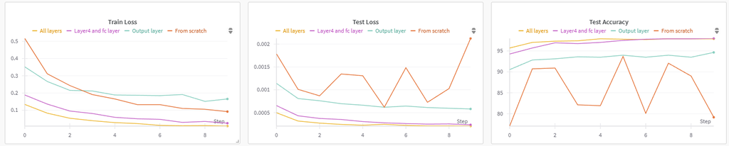

# Section 7: Visualize the result

Visualize some results from the test set.

```python
def plot_predictions(model, test_loader, device):
    model.eval()
    with torch.no_grad():
        inputs, labels = next(iter(test_loader))
        inputs, labels = inputs.to(device), labels.to(device)
        outputs = model(inputs)
        _, predicted = torch.max(outputs, 1)

        # Plot the images with their predicted labels
        plt.figure(figsize=(10, 10))
        for i in range(9):
            plt.subplot(3, 3, i+1)
            img2 = inputs[i].cpu()
            img = np.transpose(inputs[i].cpu().numpy(), (1, 2, 0))*0.29 + 0.5 # undo normalization
            img = np.clip(img, 0, 1)
            plt.imshow(img)
            plt.title(f"Pred: {dataset.classes[predicted[i].item()]}, Actual: {dataset.classes[labels[i].item()]}", fontsize=10)
            plt.axis('off')
        plt.show()
```

```python
plot_predictions(model, val_loader, device)
```

[output not shown]

# Section 8: Saving the Model

Save the state dictionary (parameters and variables) of `model3` into a file named `"final_model.safetensors"`. The [save_file](https://huggingface.co/docs/safetensors/en/index#save-tensors) function ensures that the model's weights are stored in the `.safetensors` format, which is a more secure and efficient alternative to traditional PyTorch `.pt` or `.pth` files. This allows for safe and deterministic loading of the model later for inference or further training.

```python
model_path = "final_model.safetensors"
save_file(model3.state_dict(), model_path)
```

You can list the files in the working directory to view the saved model. You can download the model file by navigating to the `Notebook` toolbar on the right, expand the `Output` tab and right click on the saved model to download the model.

[figure not shown]

# Section 8: Load a Model

Load the saved state dictionary into `loaded_state_dict`. The [load_file](https://huggingface.co/docs/safetensors/en/index#load-tensors) function retrieves the model parameters stored in the `safetensors` format, which can then be used to initialize a model for inference or further training. However, note that this only loads the state dictionary — you still need to load it into a model instance using `model.load_state_dict(loaded_state_dict)`.

```python
model_path = "final_model.safetensors"
loaded_state_dict = load_file(model_path)
```

Reconstruct the model without the ImageNet pretrained weights (`weights = None`) and without creating an optimizer (`return_optimizer=False`). Then, load the previously saved weights into the final_model. This process effectively restores the trained model for inference or further training.

```python
config =  {
    'weights'         : None,
    'finetuned_layers': None
}
```

```python
final_model = build_model(num_classes, config, device, return_optimizer=False)
final_model.load_state_dict(loaded_state_dict)
final_model = final_model.to(device)
```

```
Weights         : None
Finetuned layer : None
```

```python
test_loss, test_acc = evaluate(final_model, val_loader, loss_function, device)
print('test_acc =', test_acc)
```

```
test_acc = 97.89674952198853
```

--- End of Lab07 ---